# Red Wine Quality Analysis by Meili

```
## 'data.frame':    1599 obs. of  13 variables:
##  $ X                   : int  1 2 3 4 5 6 7 8 9 10 ...
##  $ fixed.acidity       : num  7.4 7.8 7.8 11.2 7.4 7.4 7.9 7.3 7.8 7.5 ...
##  $ volatile.acidity    : num  0.7 0.88 0.76 0.28 0.7 0.66 0.6 0.65 0.58 0.5 ...
##  $ citric.acid         : num  0 0 0.04 0.56 0 0 0.06 0 0.02 0.36 ...
##  $ residual.sugar      : num  1.9 2.6 2.3 1.9 1.9 1.8 1.6 1.2 2 6.1 ...
##  $ chlorides           : num  0.076 0.098 0.092 0.075 0.076 0.075 0.069 0.065 0.073 0.071 ...
##  $ free.sulfur.dioxide : num  11 25 15 17 11 13 15 15 9 17 ...
##  $ total.sulfur.dioxide: num  34 67 54 60 34 40 59 21 18 102 ...
##  $ density             : num  0.998 0.997 0.997 0.998 0.998 ...
##  $ pH                  : num  3.51 3.2 3.26 3.16 3.51 3.51 3.3 3.39 3.36 3.35 ...
##  $ sulphates           : num  0.56 0.68 0.65 0.58 0.56 0.56 0.46 0.47 0.57 0.8 ...
##  $ alcohol             : num  9.4 9.8 9.8 9.8 9.4 9.4 9.4 10 9.5 10.5 ...
##  $ quality             : int  5 5 5 6 5 5 5 7 7 5 ...
```

```
##  fixed.acidity   volatile.acidity  citric.acid    residual.sugar
##  Min.   : 4.60   Min.   :0.1200   Min.   :0.000   Min.   : 0.900
##  1st Qu.: 7.10   1st Qu.:0.3900   1st Qu.:0.090   1st Qu.: 1.900
##  Median : 7.90   Median :0.5200   Median :0.260   Median : 2.200
##  Mean   : 8.32   Mean   :0.5278   Mean   :0.271   Mean   : 2.539
##  3rd Qu.: 9.20   3rd Qu.:0.6400   3rd Qu.:0.420   3rd Qu.: 2.600
##  Max.   :15.90   Max.   :1.5800   Max.   :1.000   Max.   :15.500
##    chlorides       free.sulfur.dioxide total.sulfur.dioxide
##  Min.   :0.01200   Min.   : 1.00       Min.   :  6.00
##  1st Qu.:0.07000   1st Qu.: 7.00       1st Qu.: 22.00
##  Median :0.07900   Median :14.00       Median : 38.00
##  Mean   :0.08747   Mean   :15.87       Mean   : 46.47
##  3rd Qu.:0.09000   3rd Qu.:21.00       3rd Qu.: 62.00
##  Max.   :0.61100   Max.   :72.00       Max.   :289.00
##     density             pH          sulphates         alcohol
##  Min.   :0.9901   Min.   :2.740   Min.   :0.3300   Min.   : 8.40
##  1st Qu.:0.9956   1st Qu.:3.210   1st Qu.:0.5500   1st Qu.: 9.50
##  Median :0.9968   Median :3.310   Median :0.6200   Median :10.20
##  Mean   :0.9967   Mean   :3.311   Mean   :0.6581   Mean   :10.42
##  3rd Qu.:0.9978   3rd Qu.:3.400   3rd Qu.:0.7300   3rd Qu.:11.10
##  Max.   :1.0037   Max.   :4.010   Max.   :2.0000   Max.   :14.90
##     quality
##  Min.   :3.000
##  1st Qu.:5.000
##  Median :6.000
##  Mean   :5.636
##  3rd Qu.:6.000
##  Max.   :8.000
```

# Univariate Plots Section

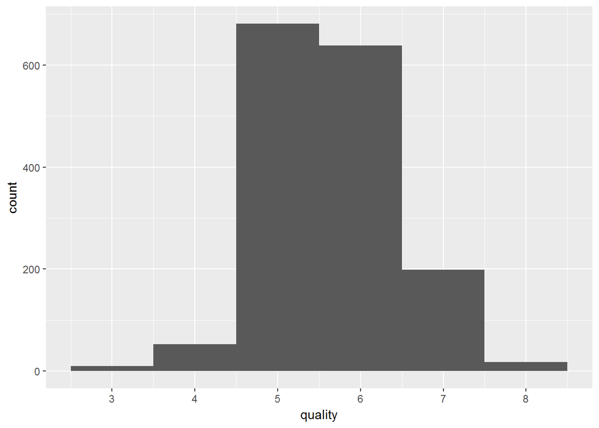

Quality are integers ranges from 3 to 8. Most wines lay in the middle at 5 and 6.

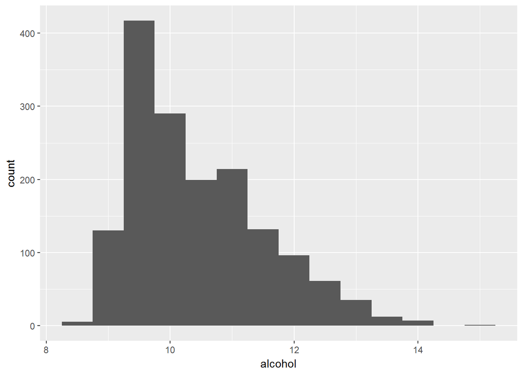

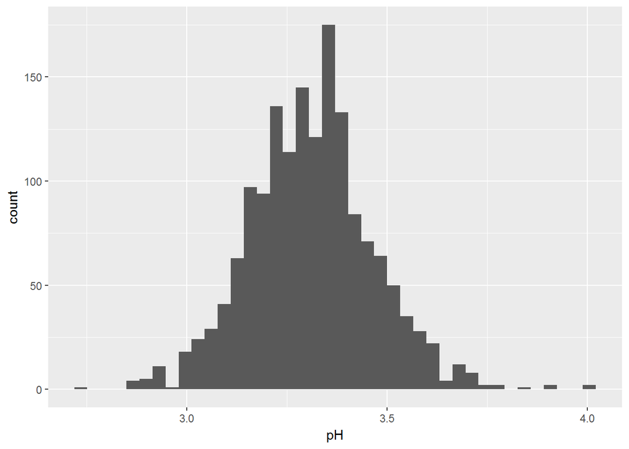

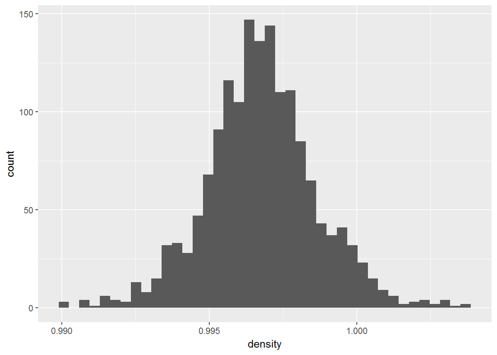

Alcohol distribution is skewed to the right, and the most wines are with around 9.5 alcohol. pH and density are mostly normally distributed around it’s center.

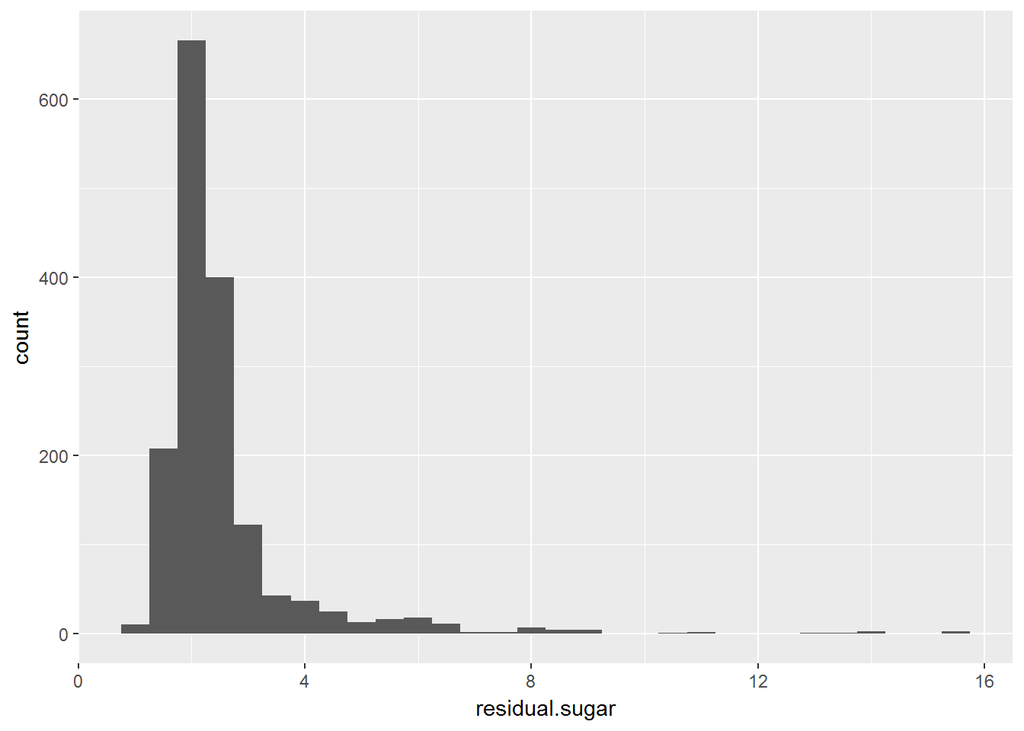

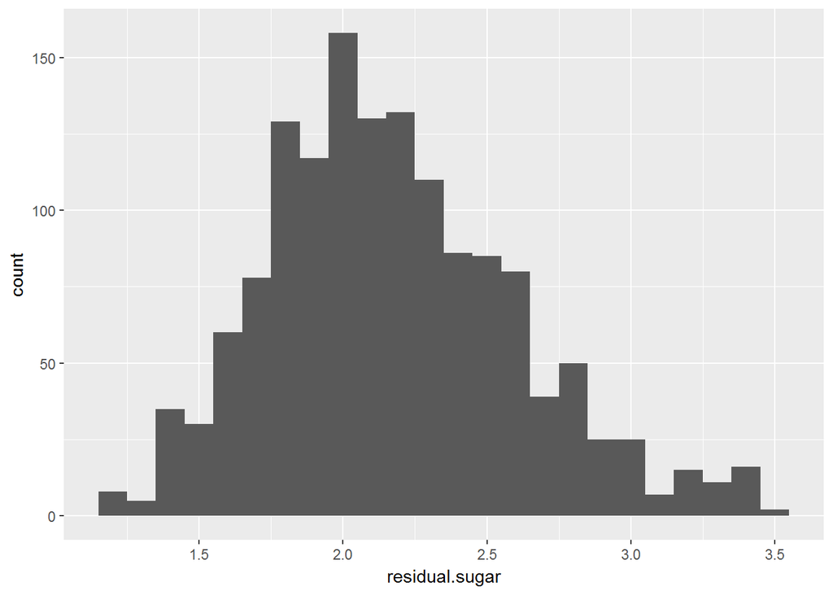

Residual sugar in wines have outliers at high sugar range. Zoom in to 90% of data and the residual sugar is normally distributed at around 2.2.

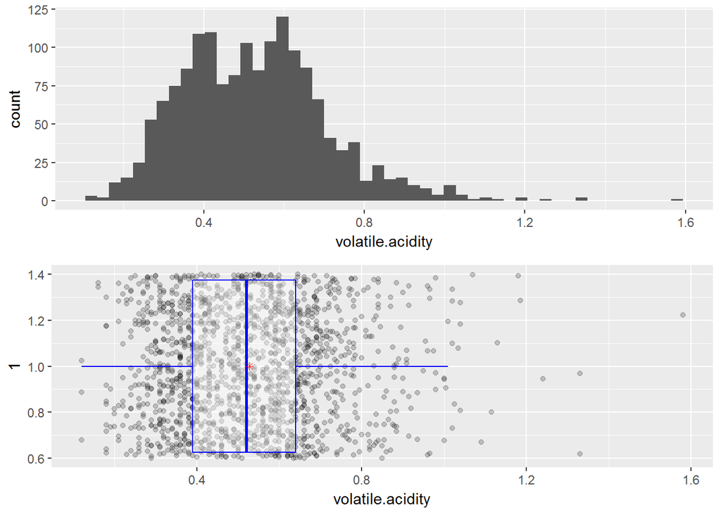

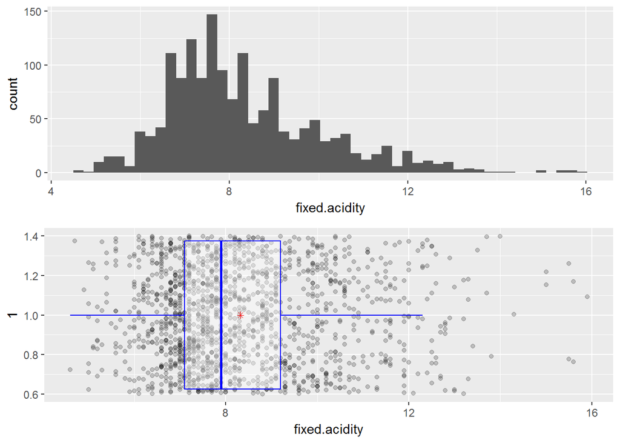

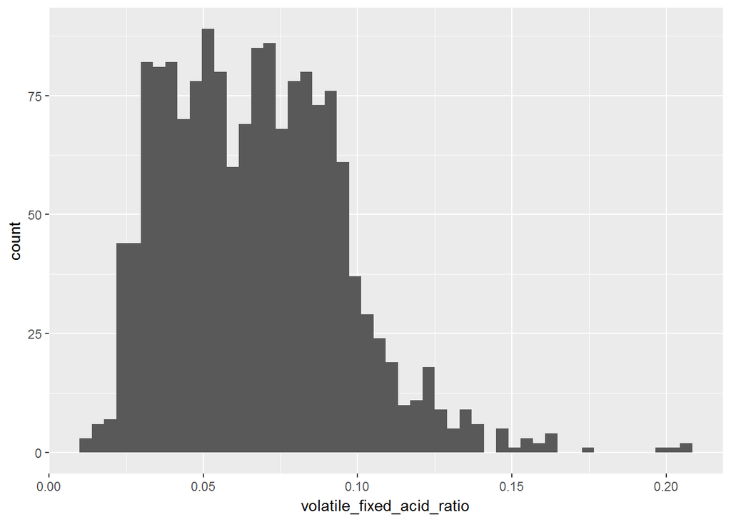

Wines contain more fixed acid than volatile acid in general. Volatile acid distribution has two peaks at around 0.4 and 0.6. Voliatile acid and fixed acid could be related, so I created a new variable for ration between voliatile acid and fixed acid. The linear scale histogram of this ratio is similar to volatile acid distriution, and most ratio is between 0.02 to 0.1.

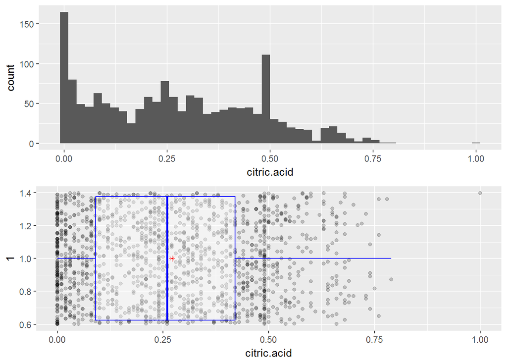

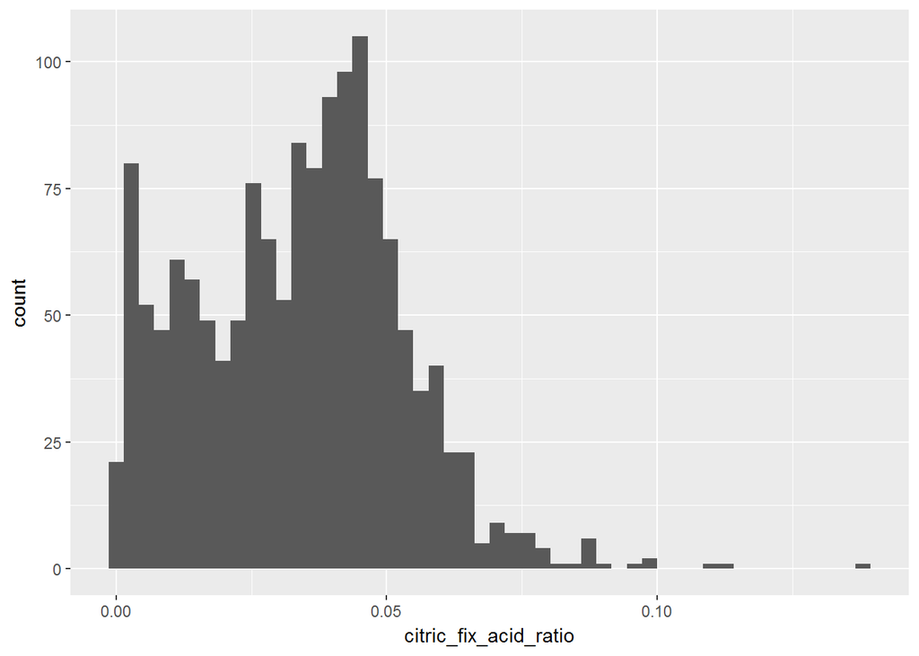

Citric acid gives a random distribution, and most wines citric acid is between 0 - 0.75. The most count occurs at 0.

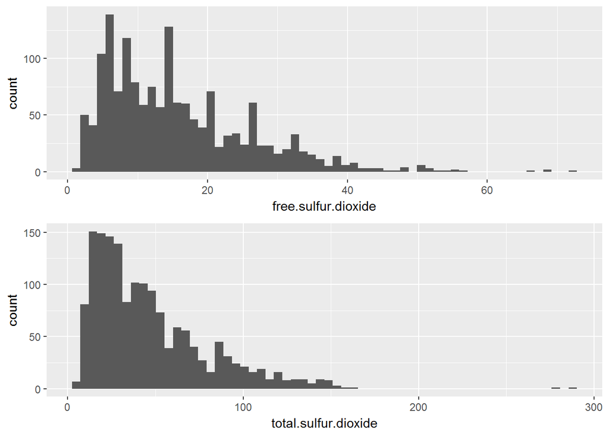

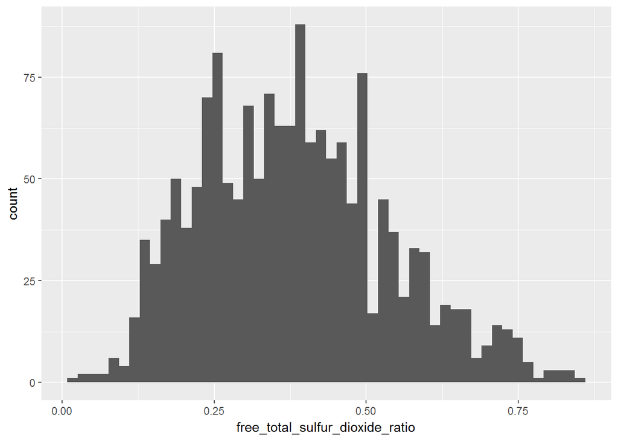

Free sulfer dioxide is lower than total sulfur dioxide. Free sulfur dioxide has a similar distribution with total sulfur dioxide, that both are like exponential decay. I create a new variable for free sulfur dioxide and total sulfur dioxide. The ratio has a normal distribution and most ratio is between 0.2 to 0.5.

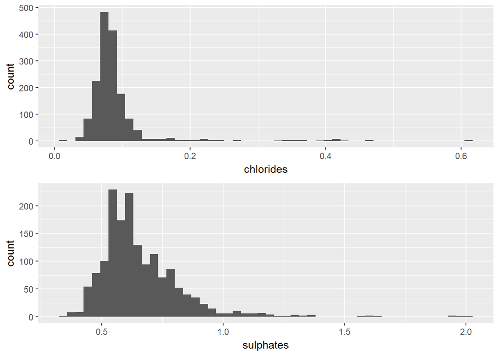

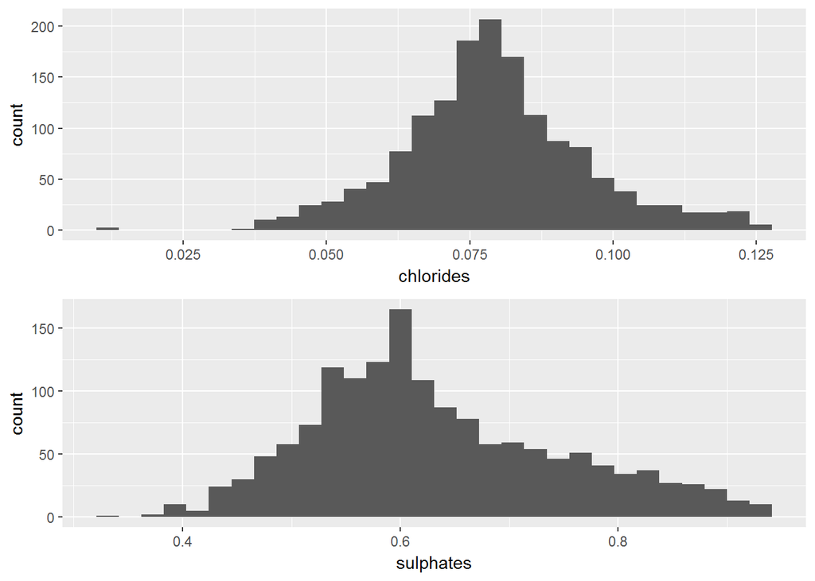

Chlorides and sulphates both show a normal distribution, with outliers and extrem at bigger values. Zoomed in graphs underneath show normal distribution for both salts.

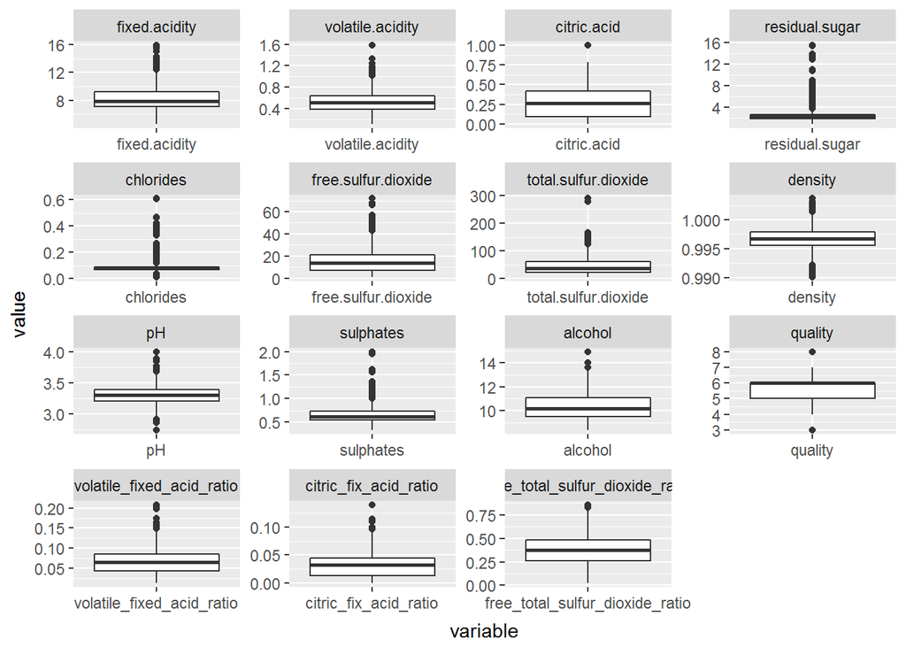

From above box plots of all variables, it shows that some variables have many outliers towards bigger values, such as chlorides, sulphates and residual sugar. Those values may affect the accuracy for bivariate and multivariate analysis. So I wrote a funcion to detect outliers which is beyond Q3+3*IQR for each columns, and remove the rows containing any outlier. The dataset is reduced to 1435 observations instead of 1599.

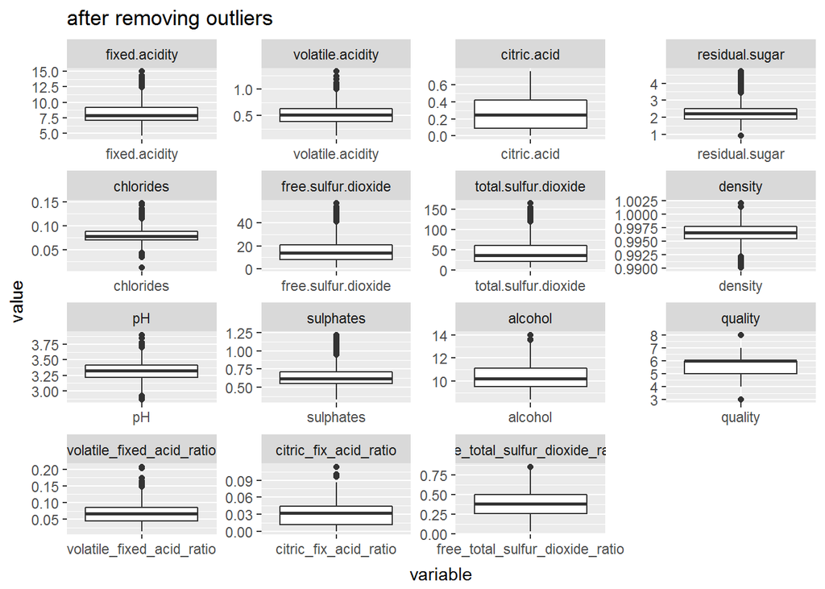

# Univariate Analysis

### What is the structure of your dataset?

Quanlity are integers range from 3 to 8. Most wines have quality of 5 or 6. pH and density are normally distributed. Free sulfur dioxide has a similar distribution with total sulfur dioxide. Sugar, chlorides and sulphates have extrems at high values, and show a normal distribution at concentrated part.

### What is/are the main feature(s) of interest in your dataset?

The main feature is quality, and other features can be directly related with quality such as alcohol, pH, sugar, density, and sulfur dioxide.

### What other features in the dataset do you think will help support your investigation into your feature(s) of interest?

The rest features have an effect on the key features. For example, fixed acidity, volatile acidity and citric acid can effect pH value. Sulphates and chlorides may relate with density.

### Did you create any new variables from existing variables in the dataset?

Yes, I creatd three new variables for ratio between fixed and volatil acid, ratio between free and total sulfur dioxide, and ratio between citric acid and fixed acid.

### Of the features you investigated, were there any unusual distributions? Did you perform any operations on the data to tidy, adjust, or change the form of the data? If so, why did you do this?

There are a few variables having outliers at bigger values. So I removed the rows with any outlier detected, and ending with 1435 observations.

# Bivariate Plots Section

[figure not shown]

Summary of pairs scatter plots: * positive relationship exclude derived parameters: fixed.acidity vs citric.acid, fixed.acidity vs density, quality vs alcohol, free.sulfur.dioxide vs total.sulfur.dioxide. * negative relationship exclude derived parameters: fixed.acidity vs pH, citric.acid vs pH, density vs pH. * derived parameters ratio between fixed.acidity and volatile.acidity, and ratio between fixed acidity and citric.acid show a better correlation with quality * some interesting patterns for alcohol vs other parameters, for example alcohol vs density. They have a strong negative correlation at the first part of data, then the trend goes flat. This is similar for alcohol vs chloride.

First, I want to study how each variable is distrbuted by qualites.

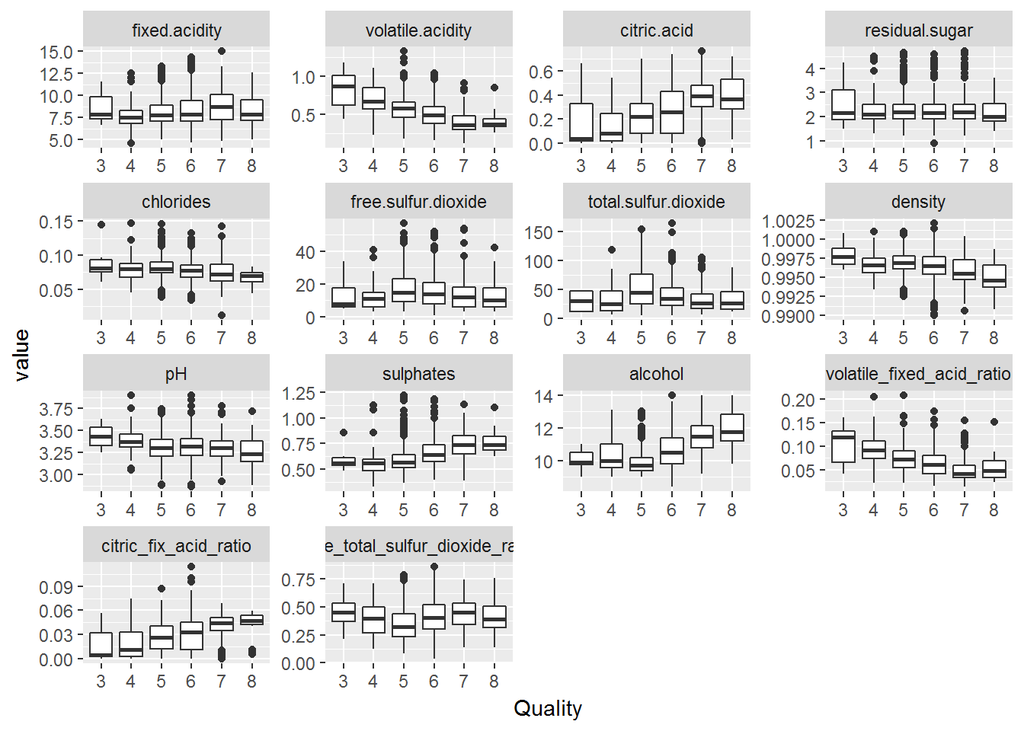

From the box chart, I can see that volatile.acidity, citric.acid, density, pH, sulphates, alcohol, ratio between fixed.acidity and volatile.acidity, and ratio between citric acid and fixed acid have varied distribution at different qualities.

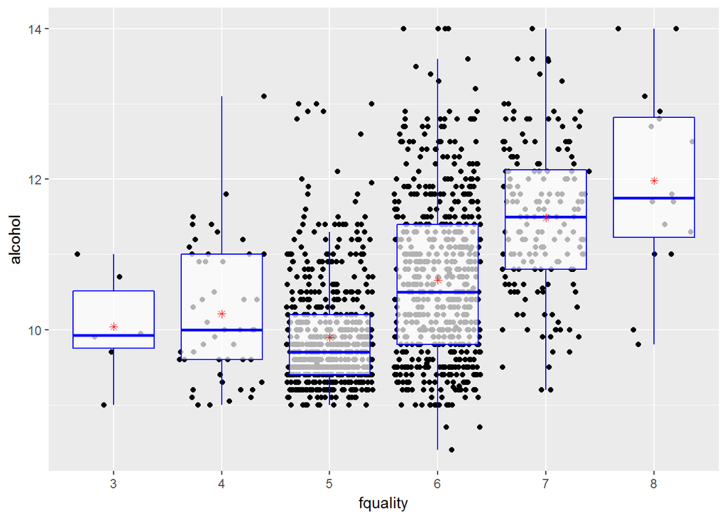

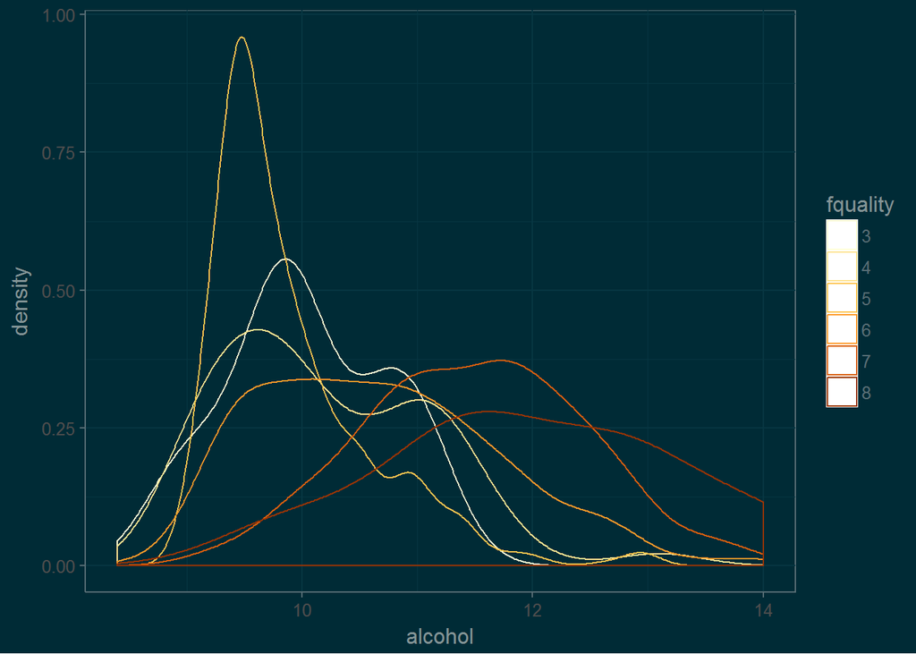

Most of wines with low quality below 5 have alcohol around or below 10. High alcohol wines with alcohol above 11 are measured as high quality. The density plot also shows the center of density migrates from low to high with quality from low to high. Alcohol should be an import factor for wine quality.

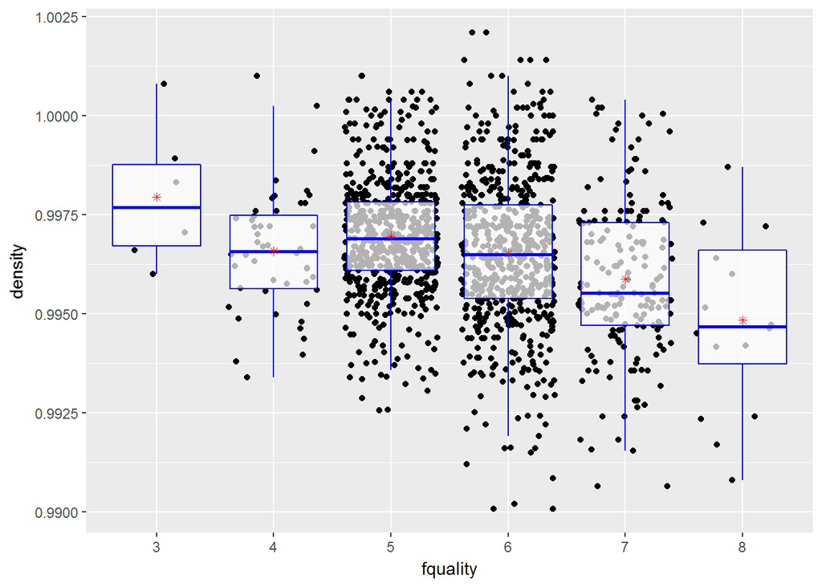

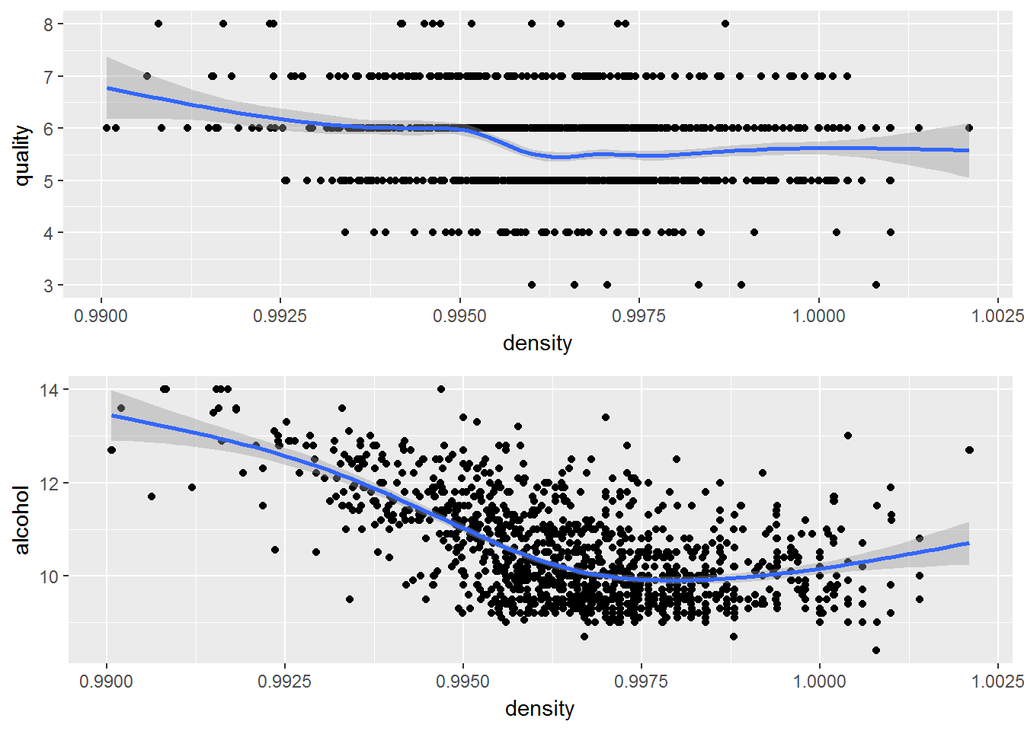

Density also has a relatively strong coorelation with quality. Its relationship is similar to the trend between density and alcohol. Since alcohol is positively correlated with quality, so the effect of density on quality is not sure of an effect of alcohol on quality or its own.

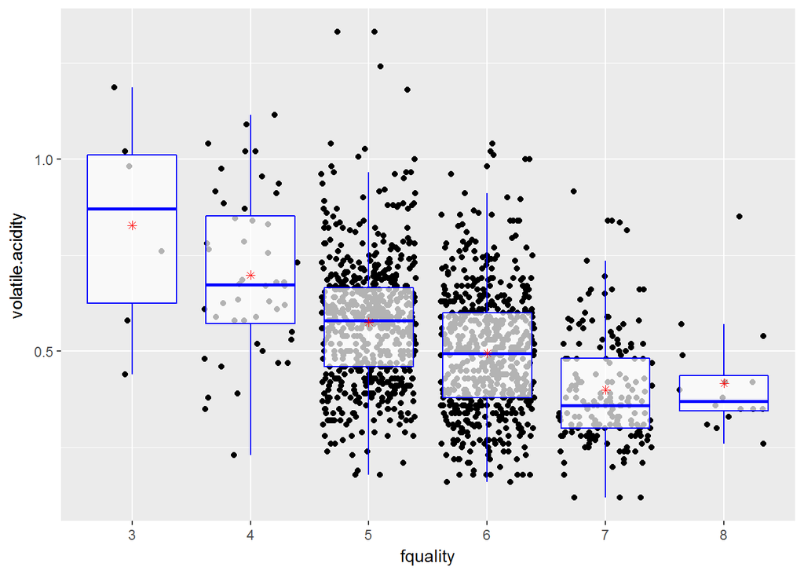

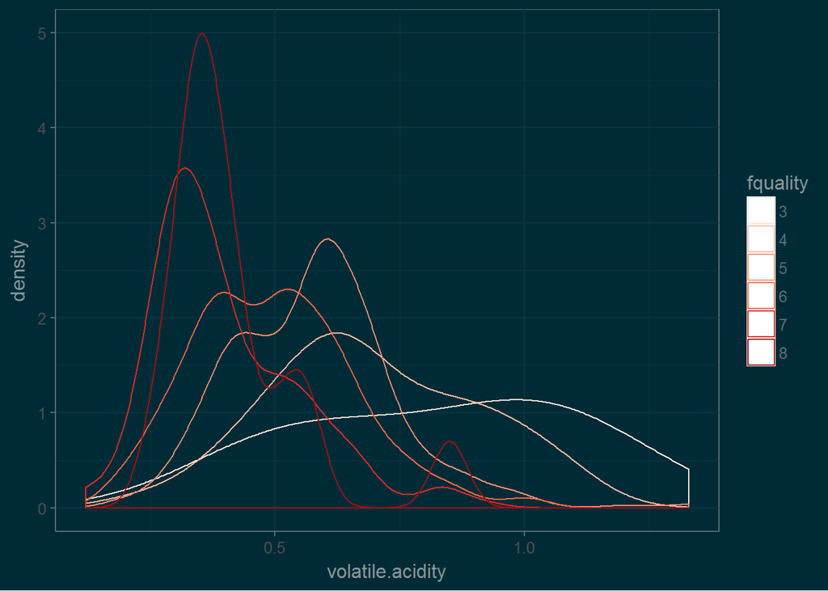

For wines with qulity greater than 6, most are in low range of volatile.acidity. So volatile.acidity is another important variable related with quality. The density plot also shows the center migrates toward lower value for volatile.acidity when quality increases.

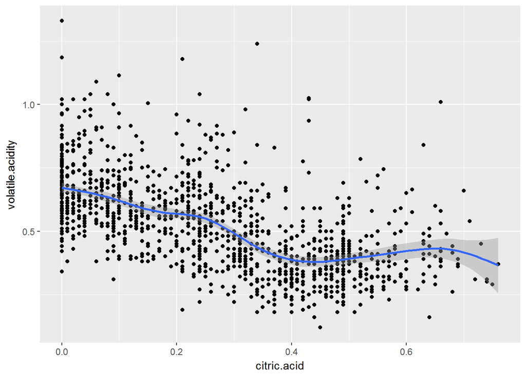

It’s intersting to see the negative relationship between volatile acidity and citric acid.

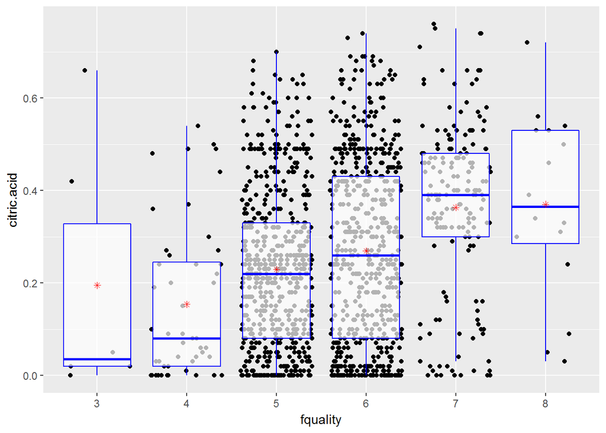

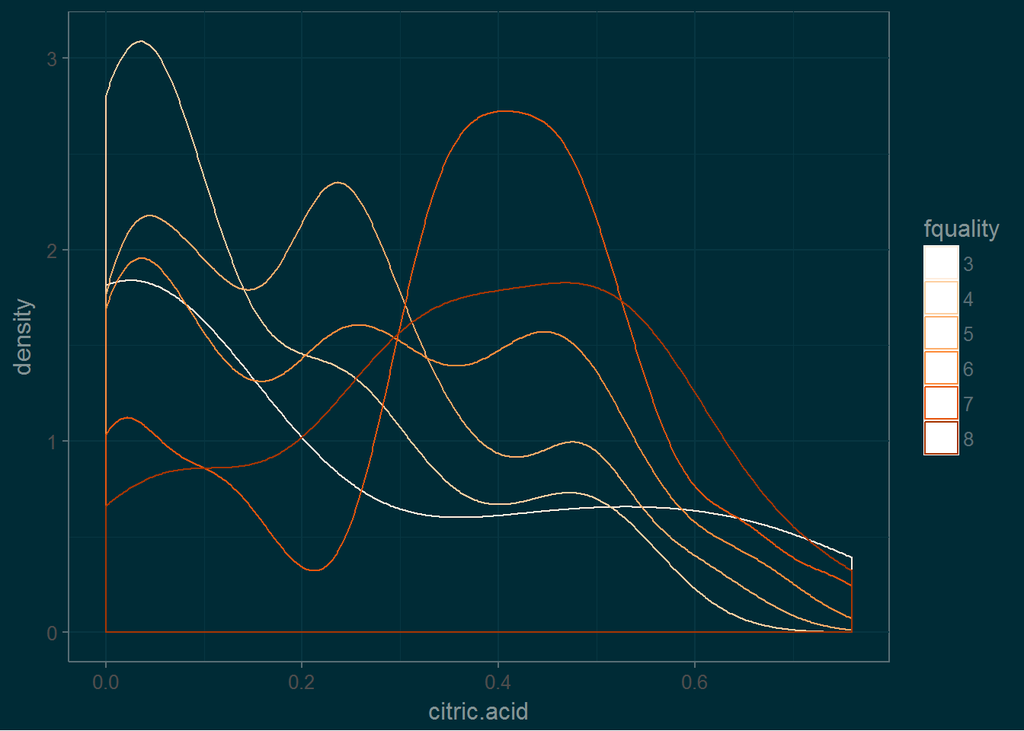

Ciric acid over all has a wide distribution across quality. The mean or median value of citric acid increases with quality from low to high. The density plot shows the height of peak at 0.1 decreases, and the height of peak at 0.5 increases, from low quality to high quality.

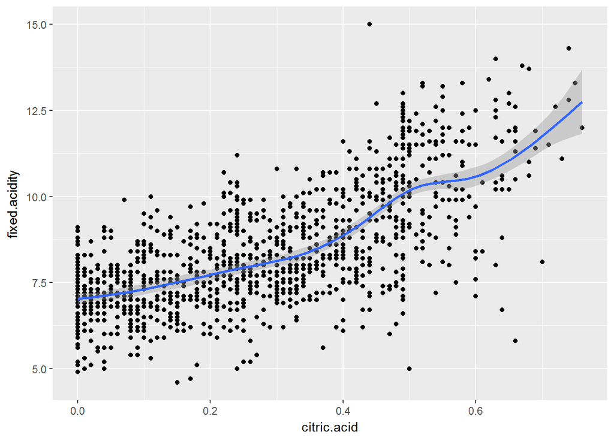

The most correlated variable with citric.acid is fixed acidity.

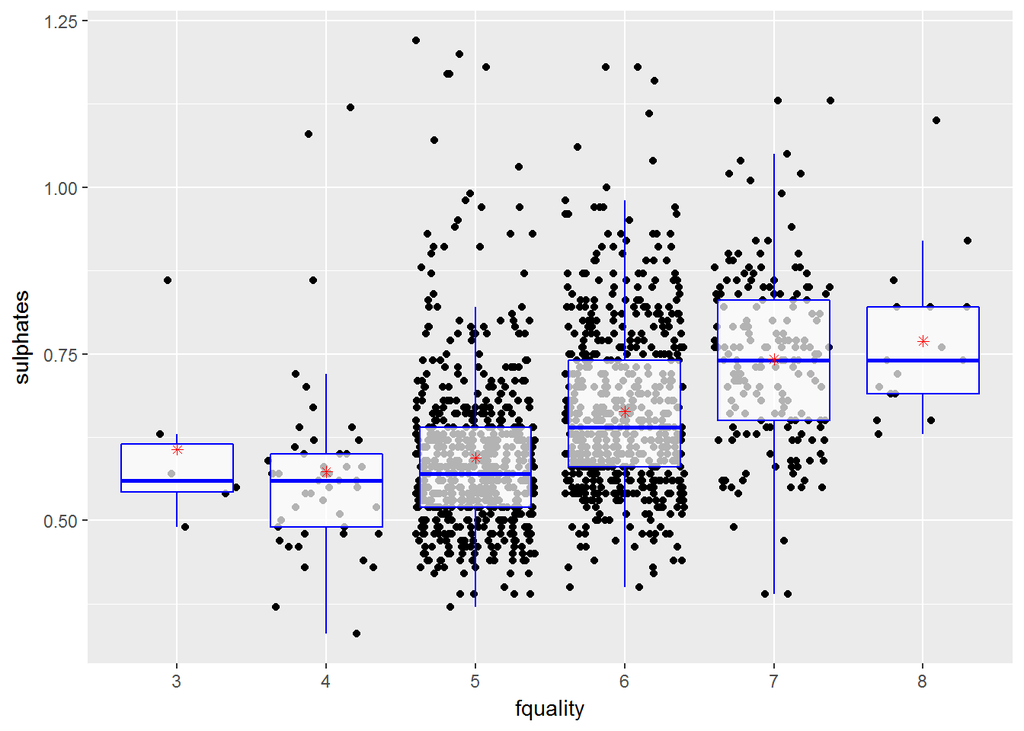

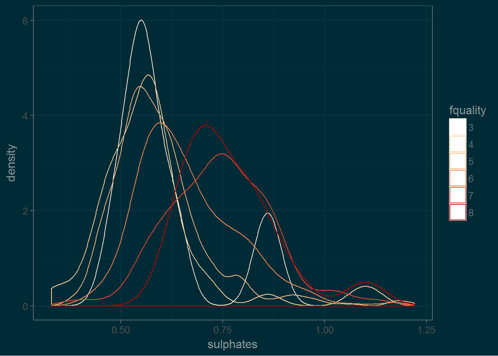

Sulphates also show varied distribution across quality. The width of density are almost the same for each quality, however the center migrates toward higher value from low to high quality.

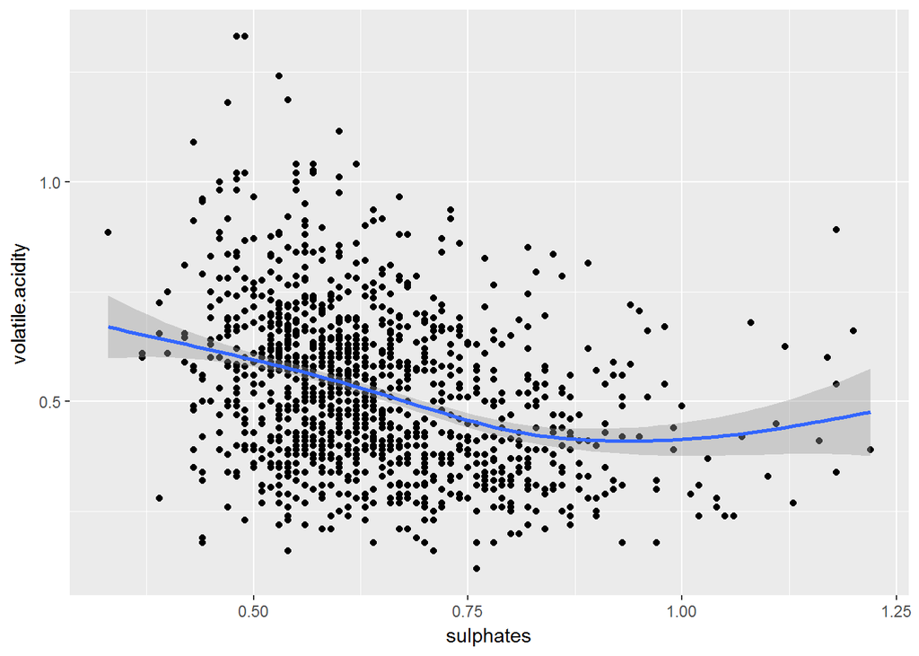

Sulphates is coorelated with volatile.acidity, and the slope changes across data which will be mentioned later in the multivariate plot session.

# Bivariate Analysis

### Did you observe any interesting relationships between the other features (not the main feature(s) of interest)?

Yes, the derived parameters calculating ratios seem to have a strong correlation with related variables. Besides, fixed acidity has a strong correlation with citric acid, density and pH, and total sulfur dioxide has strong correlation with free sulfur dioxide.

### What was the strongest relationship you found?

The strongest relationship I found is between citric acid and ratio of citric acid with fixed acid. The correlation is calculated as 0.94.

# Multivariate Plots Section

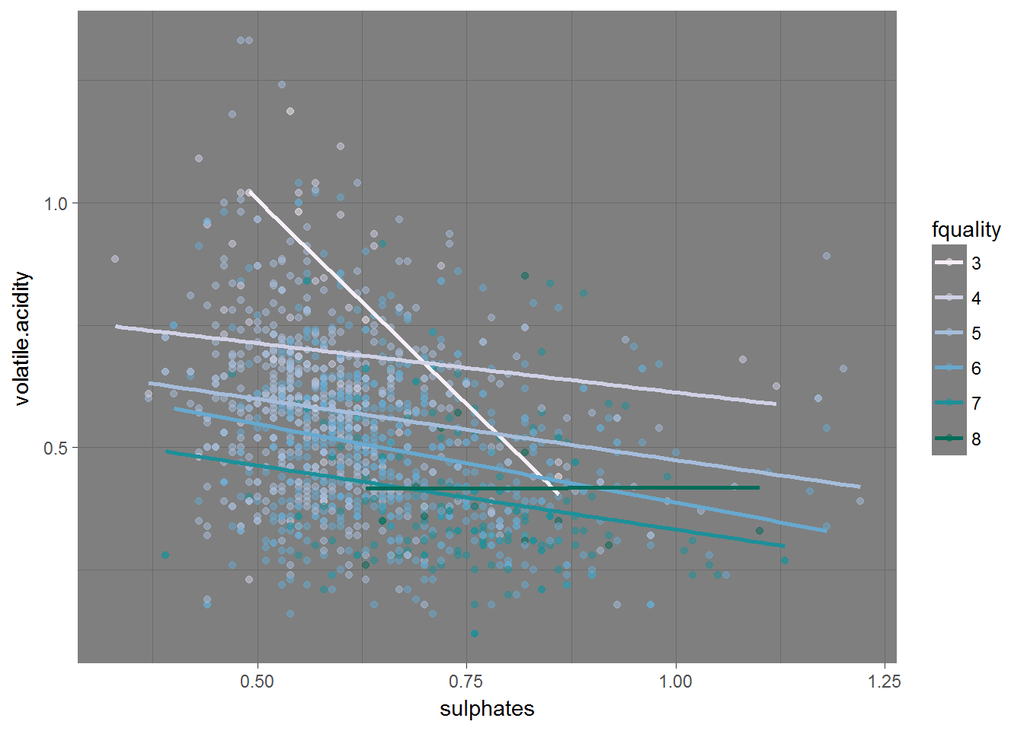

Plot sulphates vs volatile.acidity with quality as color shows high quality gathers on the right bottom along horizontal direction, and low quality gathers on the left side where sulphates are low, and vertical direction.